# Loan Data from Prosper by SHIVANAND

# Initial Analysis

### Initially I was not very well aware of the terminology used. So I took some time in understanding the variables as well as the business model of Prosper. Understanding the business model helped in framing the right questions. Prosper had 2 stints, the earlier one between 2006-2008 was not very successfull, however they made changes to their business model post 2009 July, and their financial health improved. Hence, I would like my analysis to be based on post July 2009 data

### Below are the links I used to know about the data

### https://www.prosper.com/about-us/blog/

### http://www.lendacademy.com/prosper-review/

### https://www.quora.com/profile/Sunil-Kumar-1986/answers/Prosper-P2P-lending

### https://www.quora.com/Why-is-Lending-Club-larger-than-Prosper

### https://www.quora.com/Why-do-Lending-Tree-and-Prosper-need-a-lenders-home-address

### http://www.lendacademy.com/the-difference-between-a-default-and-a-charge-off-at-lending-club/

### Before looking at the data I was keen on exploring the following questions

### 1) From an Investor perspective, which loan attributes affects EstimatedReturn

### 2) Which attributes contribute more to Loan defaults/Chargedoffs.

### 3) Number of Investors vs each Loan. Is there any correlation between Number of Investors vs loan defaults. It could be a good parameter of Investors behaviour

# Univariate Plots Section

#### In all there are 81 variables in the dataset, for now, I would like to analyse these 18 variables in detail.

#### ‘ListingCreationDate’, ‘Term’, ‘LoanStatus’,‘EstimatedEffectiveYield’, ‘EstimatedLoss’, ‘EstimatedReturn’,‘ProsperScore’, ‘ListingCategory..numeric.’, ‘EmploymentStatusDuration’, ‘OpenCreditLines’, ‘TotalInquiries’, ‘AmountDelinquent’, ‘DebtToIncomeRatio’, ‘StatedMonthlyIncome’, ‘TotalProsperPaymentsBilled’, ‘ProsperPaymentsOneMonthPlusLate’, ‘LoanOriginalAmount’, ‘Investors’

##### Reasons for selecting these columns are :

##### ListingCreationDate: I want to select listing post July 2009 period.

##### Term: curious to see how estimatedRates, defaults and chargedoff loans change based on the Term structure

##### LoanStatus: to identify the status of loans

##### EstimatedEffectiveYield: From an investor perspective, this is potentially the maximum yeild he can get

##### EstimatedReturn: to verify EstimatedReturn = EstimatedEffectiveYield - EstimatedLoss holds TRUE

##### ProsperScore: to see the relationship between customer profile vs his riskrate

##### ListingCategory..numeric.: Category of loans

##### EmploymentStatusDuration : I could also have chosen Occupation or EmploymentStatus, however, I thought EMployee monthly income + EmployeeStatusDuration would be a better predictor of employee loan repayment capability

##### OpenCreditLines: Using only OpenCreditLines since it must include OpenRevolvingAccounts as well (I understood the definitions of Credit Lines as : The amount that borrower is eligible to get, however he need not use all of it at once )

##### TotalInquiries: Tells us, if he is a new customer or an old one

##### AmountDelinquent: Tells us, how much a customer has defaulted in previous loans

##### DebtToIncomeRatio: Tells us about the financial health of customer

##### StatedMonthlyIncome:

##### TotalProsperPaymentsBilled: Number of times a customer has paid back for earlier loans

##### ProsperPaymentsOneMonthPlusLate: number of times he has not paid back for earlier loans

##### LoanOriginalAmount: amount of money applied by the customer

##### Investors : Number of Investors invested in the loan

```
## 'data.frame':    113937 obs. of  18 variables:
##  $ ListingCreationDate            : Factor w/ 113064 levels "2005-11-09 20:44:28.847000000",..: 14184 111894 6429 64760 85967 100310 72556 74019 97834 97834 ...
##  $ Term                           : int  36 36 36 36 36 60 36 36 36 36 ...
##  $ LoanStatus                     : Factor w/ 12 levels "Cancelled","Chargedoff",..: 3 4 3 4 4 4 4 4 4 4 ...
##  $ EstimatedEffectiveYield        : num  NA 0.0796 NA 0.0849 0.1832 ...
##  $ EstimatedLoss                  : num  NA 0.0249 NA 0.0249 0.0925 ...
##  $ EstimatedReturn                : num  NA 0.0547 NA 0.06 0.0907 ...
##  $ ProsperScore                   : num  NA 7 NA 9 4 10 2 4 9 11 ...
##  $ ListingCategory..numeric.      : int  0 2 0 16 2 1 1 2 7 7 ...
##  $ EmploymentStatusDuration       : int  2 44 NA 113 44 82 172 103 269 269 ...
##  $ OpenCreditLines                : int  4 14 NA 5 19 17 7 6 16 16 ...
##  $ TotalInquiries                 : num  3 5 1 1 9 2 0 16 6 6 ...
##  $ AmountDelinquent               : num  472 0 NA 10056 0 ...
##  $ DebtToIncomeRatio              : num  0.17 0.18 0.06 0.15 0.26 0.36 0.27 0.24 0.25 0.25 ...
##  $ StatedMonthlyIncome            : num  3083 6125 2083 2875 9583 ...
##  $ TotalProsperPaymentsBilled     : int  NA NA NA NA 11 NA NA NA NA NA ...
##  $ ProsperPaymentsOneMonthPlusLate: int  NA NA NA NA 0 NA NA NA NA NA ...
##  $ LoanOriginalAmount             : int  9425 10000 3001 10000 15000 15000 3000 10000 10000 10000 ...
##  $ Investors                      : int  258 1 41 158 20 1 1 1 1 1 ...
```

```
## [1] "The following are Factor variables: ListingCreationDate, LoanStatus, "
```

```
## [1] "Convert ListingCreationDate from factor to Date format"
```

```
## [1] "Convert Term, ProsperScore, ListingCategory to Factor variables and ListingCreationDate to Date variable"
```

[output not shown]

```
## [1] "Change column name of ListingCategory..numeric. to ListingCategory"
```

```
## [1] "Confirm the structure with above changes"
```

```
## 'data.frame':    84672 obs. of  18 variables:
##  $ ListingCreationDate            : Date, format: "2014-02-27" "2012-10-22" ...
##  $ Term                           : Factor w/ 3 levels "12","36","60": 2 2 2 3 2 2 2 2 3 2 ...
##  $ LoanStatus                     : Factor w/ 12 levels "Cancelled","Chargedoff",..: 4 4 4 4 4 4 4 4 4 8 ...
##  $ EstimatedEffectiveYield        : num  0.0796 0.0849 0.1832 0.1157 0.2382 ...
##  $ EstimatedLoss                  : num  0.0249 0.0249 0.0925 0.0449 0.1275 ...
##  $ EstimatedReturn                : num  0.0547 0.06 0.0907 0.0708 0.1107 ...
##  $ ProsperScore                   : Factor w/ 11 levels "1","2","3","4",..: 7 9 4 10 2 4 9 11 7 4 ...
##  $ ListingCategory                : Factor w/ 20 levels "0","1","2","3",..: 3 16 3 2 2 3 7 7 2 2 ...
##  $ EmploymentStatusDuration       : int  44 113 44 82 172 103 269 269 300 1 ...
##  $ OpenCreditLines                : int  14 5 19 17 7 6 16 16 2 7 ...
##  $ TotalInquiries                 : num  5 1 9 2 0 16 6 6 2 4 ...
##  $ AmountDelinquent               : num  0 10056 0 0 0 ...
##  $ DebtToIncomeRatio              : num  0.18 0.15 0.26 0.36 0.27 0.24 0.25 0.25 0.12 0.18 ...
##  $ StatedMonthlyIncome            : num  6125 2875 9583 8333 2083 ...
##  $ TotalProsperPaymentsBilled     : int  NA NA 11 NA NA NA NA NA NA NA ...
##  $ ProsperPaymentsOneMonthPlusLate: int  NA NA 0 NA NA NA NA NA NA NA ...
##  $ LoanOriginalAmount             : int  10000 10000 15000 15000 3000 10000 10000 10000 13500 4000 ...
##  $ Investors                      : int  1 158 20 1 1 1 1 1 19 1 ...
```

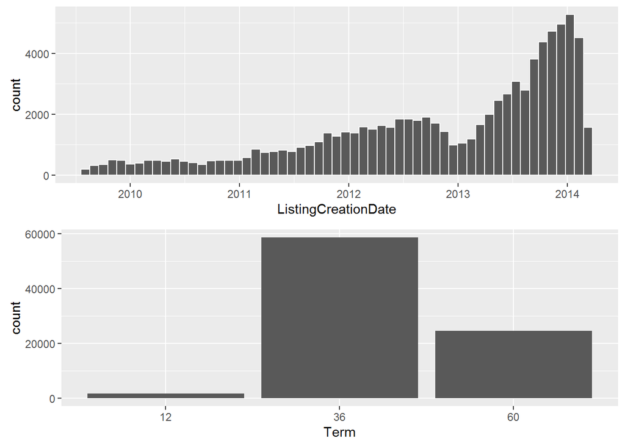

```
## [1] "Summary ListingCreationDate"
```

```
##         Min.      1st Qu.       Median         Mean      3rd Qu.
## "2009-08-01" "2012-02-15" "2013-03-29" "2012-11-06" "2013-10-26"
##         Max.
## "2014-03-10"
```

```
## [1] "Summary Term"
```

```
##    12    36    60
##  1613 58514 24545
```

```
## ListingCreationDate distribution is left skewed, so more customers started listing from the year 2013.  Most customers take 3 year loans, followed by 5 year loans.
```

[figure not shown]

```
## [1] "Summary LoanStatus"
```

```
##              Cancelled             Chargedoff              Completed
##                      0                   5326                  19501
##                Current              Defaulted FinalPaymentInProgress
##                  56576                    997                    205
##   Past Due (>120 days)   Past Due (1-15 days)  Past Due (16-30 days)
##                     16                    806                    265
##  Past Due (31-60 days)  Past Due (61-90 days) Past Due (91-120 days)
##                    363                    313                    304
```

```
## [1] "Good number of loans are completed, however the chargedoff, defaulted loans are also quite high. Interested to check what is the customer profile and preferences of these customers, Performed this analysis inBivariate Plots Section"
```

```
## [1] "Summary ProsperScore"
```

```
##     1     2     3     4     5     6     7     8     9    10    11
##   989  5766  7639 12594  9807 12271 10581 12008  6843  4718  1456
```

```
## [1] "Scores are normally distributed. Perhaps this is the business model of Prosper to follow a normal distribution while giving ratings. I am interested see summary statistics of scores for different LoanStatus, (performed this analysis in Bivariate Plots Section)"
```

```
## [1] "Summary ListingCategory"
```

```
##     0     1     2     3     5     6     7     8     9    10    11    12
##    20 53085  6783  5286   263  2230  9180   199    85    91   217    59
##    13    14    15    16    17    18    19    20
##  1996   876  1522   304    52   885   768   771
```

```
## [1] "Majority people take loans for Debt Consolodation purposes followed by Other, Home Improvement, Business. Least preffered categories are RV, Boat, Cosmetic Purposes"
```

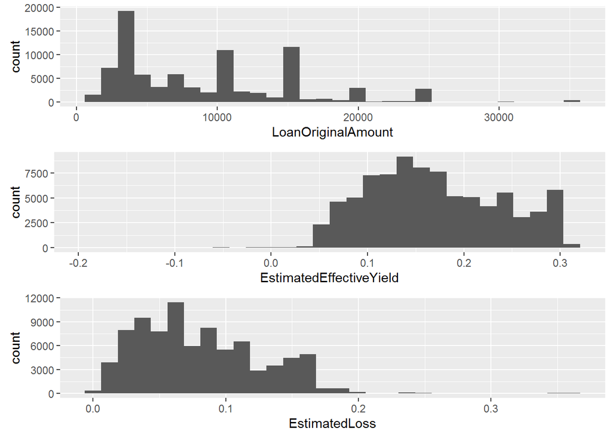

```
## [1] "Summary LoanOriginalAmount"
```

```
##    Min. 1st Qu.  Median    Mean 3rd Qu.    Max.
##    1000    4000    7500    9094   13750   35000
```

```
## [1] "Minimum Loan amount is 1000$, while maximum is 35,000$. It is interesting to observe the mode, The graph is replotted with different binwidth below to observe the mode"
```

```
## [1] "Summary EstimatedEffectiveYield"
```

```
##    Min. 1st Qu.  Median    Mean 3rd Qu.    Max.
## -0.1827  0.1166  0.1615  0.1688  0.2243  0.3199
```

```
## [1] "mean and median are approximately equal to 16.7%"
```

```
## [1] "Summary EstimatedLoss"
```

```
##    Min. 1st Qu.  Median    Mean 3rd Qu.    Max.
## 0.00490 0.04240 0.07240 0.08034 0.11200 0.36600
```

```
## [1] "While the maximum loss is 36.6%, the mean and median are 8% and 7.2% resp, suggesting a slighly positive skew"
```

```
## [1] "Replotting after readjusting the binwidths"
```

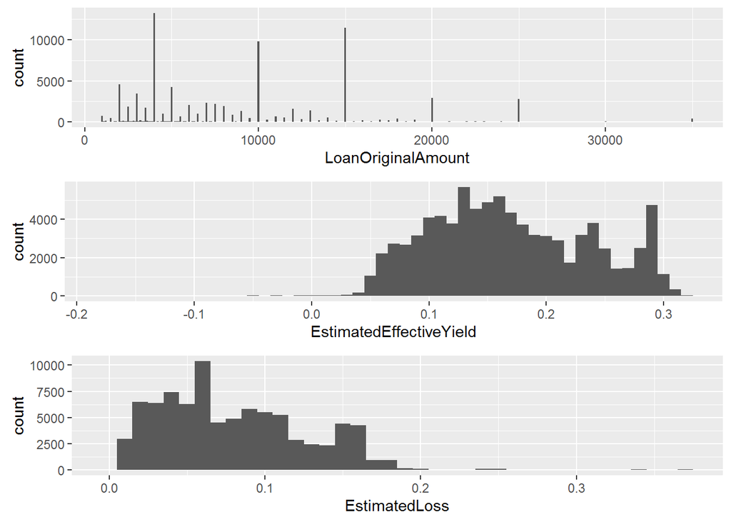

```
## [1] " LoanOriginalAmount It is a trimodal distribution at 4000, 15000 and 10000 Euros. EsimatedEffectiveYield appears to be slightly bi-modal or platykurptic distribution whereas EstimatedLoss follows platykurptic distibution with right tails"
```

```
## [1] "Creating a new variable \"EstimatedReturnCalc\" as EstimatedEffectiveYield - EstimatedLoss. This is compared with EstimatedReturn in the original dataset to see if they are the same"
```

```
## sum(df$EstimatedReturn):  8136.419
```

```
## sum(df$EstimatedReturnCalc):  7494.006
```

```
## [1] "There seems to be some error here, as according to the definitions EstimatedReturn = EstimatedEffectiveYield - EstimatedLoss, but that does not seem to the case here."
```

```
## [1] "Create density plots to show the difference between EstimatedReturn(Black Color)  and EstimatedReturnCalc(Red Color)"
```

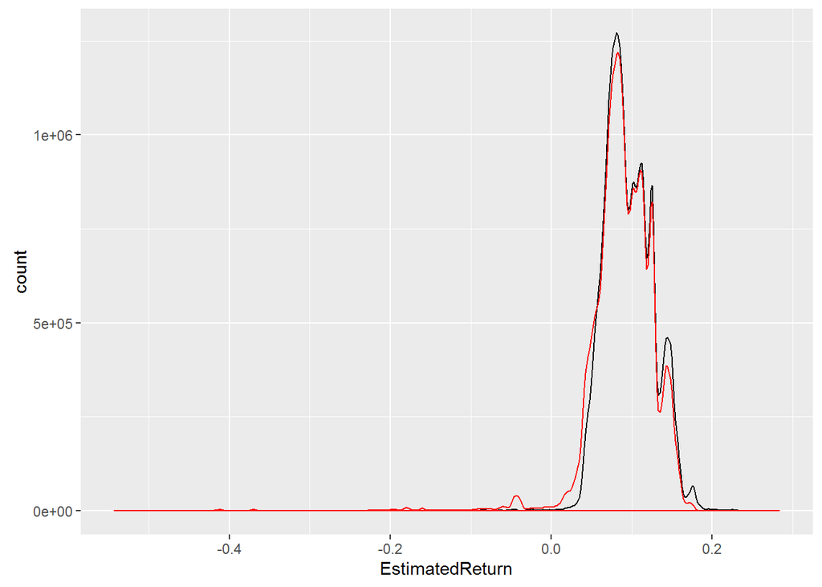

```
## [1] "This is contradictory to the defination given in the document. In the proceeding analysis, I consider EstimatedReturn and not EstimatedReturnCalc"
```

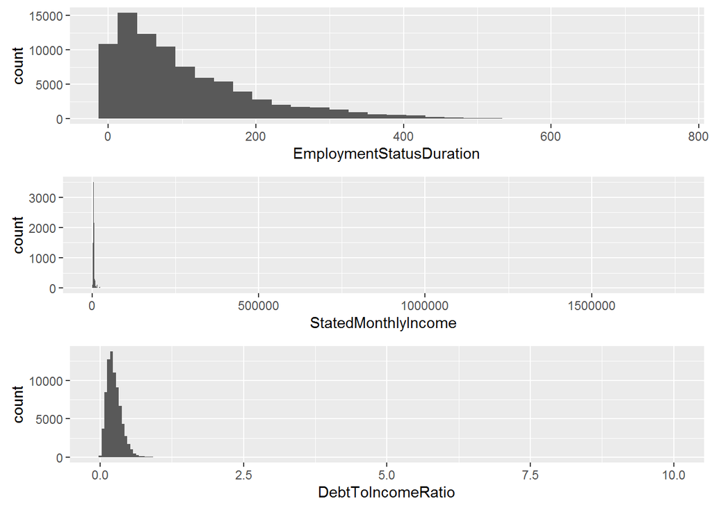

```
## [1] "Summary of EmploymentStatusDuration"
```

```
##    Min. 1st Qu.  Median    Mean 3rd Qu.    Max.    NA's
##     0.0    30.0    74.0   103.1   148.0   755.0      19
```

```
## [1] "Median Duration is 74 months. The maximum value is 755 months. It is very hard to belive this number. Would like to analyse these customers in Multivariate analysis"
```

```
## [1] "Summary of StatedMonthlyIncome"
```

```
##    Min. 1st Qu.  Median    Mean 3rd Qu.    Max.
##       0    3442    5000    5933    7083 1750000
```

```
## [1] "Clearly there are a lot of outliers, however mean and median are fairly close, so we can consider the distribution as fairly normal, although a better representaion is a positive skewed distribution"
```

```
## [1] "Summary of DebtToIncomeRatio"
```

```
##    Min. 1st Qu.  Median    Mean 3rd Qu.    Max.    NA's
##   0.000   0.150   0.220   0.259   0.320  10.010    7281
```

```
## [1] "Again, there are a lot of outliers, but redrawing the distribution after removing them, it should look fairly normal "
```

```
## [1] "The above distributions are not very informative. Hence, change the scale of EmploymentStatusDuration to logScale, remove outliers of StatedMonthlyIncome, remove outliers of DebtToIncomeRatio. Redrawing after these changes"
```

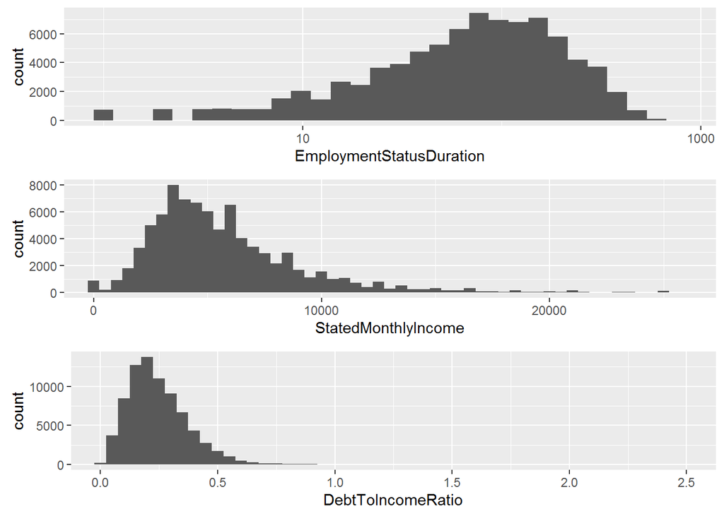

```
## [1] "Now EmploymentStatusDuration distribution looks normal. The other 2 distributions are positively skewed distributions with long tails"
```

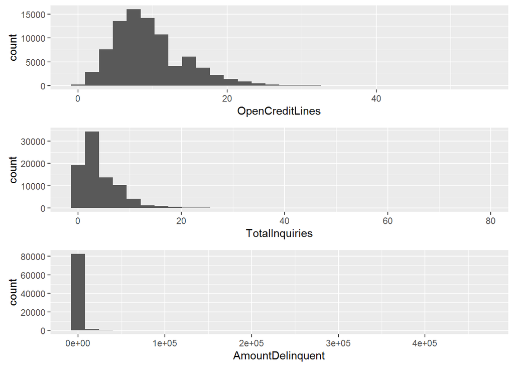

```
## [1] "Summary of OpenCreditLines"
```

```
##    Min. 1st Qu.  Median    Mean 3rd Qu.    Max.
##   0.000   6.000   9.000   9.528  12.000  54.000
```

```
## [1] "As mean and median are fairly close, the distribution is fairly normal, however there are outliers, as maximum value is quite high"
```

```
## [1] "Summary of TotalInquiries"
```

```
##    Min. 1st Qu.  Median    Mean 3rd Qu.    Max.
##   0.000   2.000   3.000   4.287   6.000  78.000
```

```
## [1] "This is a discrete distribution with a positive skew"
```

```
## [1] "Summary of AmountDelinquent"
```

```
##     Min.  1st Qu.   Median     Mean  3rd Qu.     Max.
##      0.0      0.0      0.0    952.5      0.0 463900.0
```

```
## [1] "There must very few records as, minimum, 1st Quartile, 2nd quartile and 3rd quartile are all zero."
```

```
## [1] "Redrawing AmountDelinquent as LogNormal distributions. Note that I have excluded majority of records (73681) as its value is 0"
```

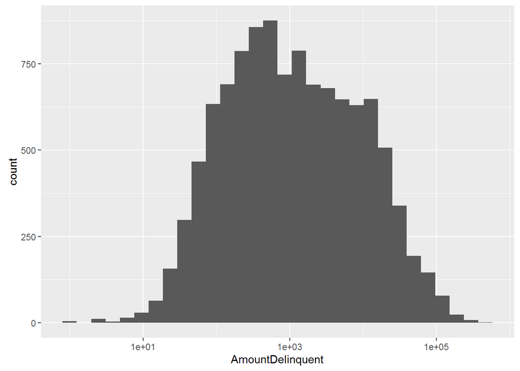

```
## [1] "This does look normal, or maybe platykurtic "
```

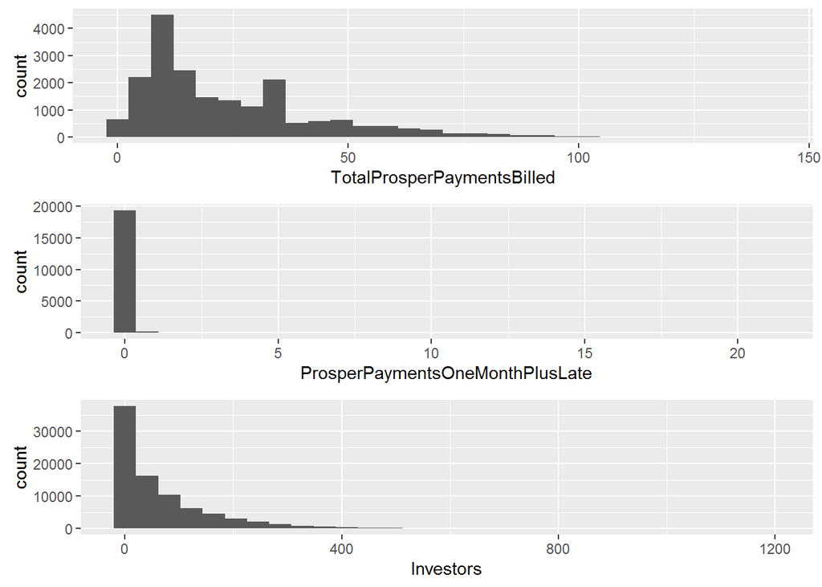

```
## [1] "Summary of TotalProsperPaymentsBilled"
```

```
##    Min. 1st Qu.  Median    Mean 3rd Qu.    Max.    NA's
##    0.00   10.00   18.00   24.34   35.00  141.00   64990
```

[output not shown]

```
## [1] "summary of ProsperPaymentsOneMonthPlusLate"
```

```
##    Min. 1st Qu.  Median    Mean 3rd Qu.    Max.    NA's
##    0.00    0.00    0.00    0.05    0.00   21.00   64990
```

```
## [1] "Again Many customers are new as 64990 records are NULL, meaning they are first time customers, also only a fraction of people are paying quite late as 3rd quartile is 0 and mean is also close to 0. Multivariate plots might give better picture"
```

```
## [1] "summary of Investors"
```

```
##    Min. 1st Qu.  Median    Mean 3rd Qu.    Max.
##     1.0     1.0    31.0    68.1    97.0  1189.0
```

```
## [1] "Looks like a lognormal distribution. However atleast 25% of investments are made by single investor, would like to see what types of loan they invest in. "
```

```
## [1] "Lognormal distribution of Investors and plotting a new distribution for ProsperPaymentsOneMonthPlusLate > 0 "
```

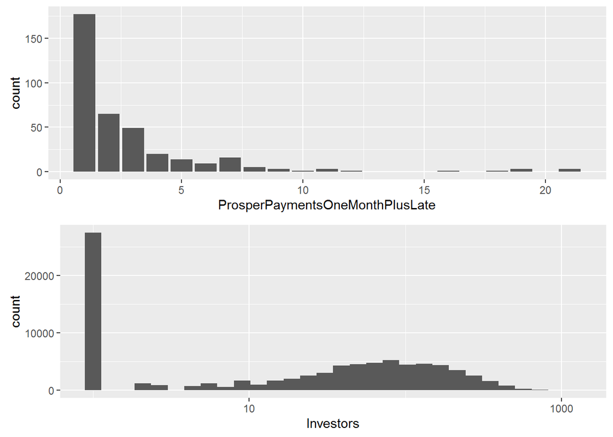

```
## [1] "ProsperPaymentsOneMonthPlusLate shows that delays upto 5 payments are common, with 1 and 2 delays in payments being more common. Also the Investors distribution is platykurptic if we ignore single Investors.There are around 26000 investors who invest completely in a loan"
```

```
## [1] "Create ProsperPaymentsRatio column, it contains the ratio of paymentsOneMonthPlusLate and TotalProsperPaymentsBilled"
```

# Univariate Analysis

### What is the structure of your dataset?

#### The original dataset contains 113937 records of 81 variables, however I choose 84672 records of 18 variables. Prosper changed their business model post July 2009, and I considered only those records.

#### The reasons for choosing these 18 variables are explained above. They were chosen in accordance to my objective, which are, as explained above:

#### 1) From an Investor perspective, which loan attributes contribute to EstimatedReturn

#### 2) Which attributes contribute more to Loan defaults/charge offs.

### 3) Number of Investors vs each Loan. Is there any correlation between Number of Investors vs loan defaults.

#### To summarise:

#### There are 4 factor variables:

##### ProsperScore - Clearly follows a normal distribution, perhaps the algorithm is designed that way

##### ListingCategory - Majority people take loans for Debt Consolodation purposes followed by Other, Home Improvement, Business. Least preffered categories are RV, Boat, Cosmetic Purposes

#### Also, among the numeric parameters

##### EstimatedEffectiveYield - Mean is 16.88% and the distribution is platokurptic

##### EstimatedReturn - Mean is 9.6% and the distribution is normal

##### LoanOriginalAmount - Tri modal distribution with peaks at 4000$, 10000$ and 15000$

##### StatedMonthlyIncome - Mean of 5933$ , with a skightly positive skewed distribution

##### DebtToIncomeRatio - There are a lot of outliers with mean as 25.9%

##### EmployeeStatusDuration - Median Duration is 74 months, with maximum value being 755 months, this value seems highly improbable

##### Just a little more than quartile of Listings are Invested by Single Investors.

##### Other variables like OpenCreditLines, TotalInquiries and AmountDelinquent were considered to estimate customers profile.

#### All variables and their distributions are discussed in detail in the analysis section

### What is/are the main feature(s) of interest in your dataset?

##### EstimatedReturn is definately a key feature of Interest. Apart from it, I am also keen to note the factors influencing ‘Chargedoff’ and ‘Cancelled’ loan status.

### What other features in the dataset do you think will help support your investigation into your feature(s) of interest?

##### ProsperScore: A factor variable specifying the riskiness associated with the loan is an important variable.

##### From a customer segmentation perspective: StatedmonthlyIncome, EmployeeStatusDuration, OpenCreditLines, DebtToIncomeRatio and AmountDeliquent might help in addressing factors responsible for Chargedoff and Cancelled Loans.

##### Above factors along with Number of Investors and OriginalLoanAmount might have a say in estimating Returns

### Did you create any new variables from existing variables in the dataset?

##### In the documents it was mentioned that EstimatedReturn as the difference between EstimatedEffectiveYield and EstimatedLoss. Thus, I created a variable EstimatedReturnCalc as EstimatedEffectiveYield - EstimatedLoss to test this statement. And I observed that the two namely, EstimatedReturn and EstimatedReturnCalc are not equal.

##### Another Variable ProsperPaymentsRatio = ProsperPaymentsOneMonthPlusLate/ TotalProsperPaymentsBilled to see the fraction of latepayments over total payments.

### Of the features you investigated, were there any unusual distributions? Did you perform any operations on the data to tidy, adjust, or change the form of the data? If so, why did you do this?

##### Yes, I observed that few variables like Investors, EmploymentStatusDuration and AmountDelinquent were log normally distributed Also, there were a high number of outliers for a lot of variables like StatedMonthlyIncome, DebtToIncomeRatio and OpenCreditLines. But I observed that these distributions were fairly normal if these outliers were excluded. I had done these transformations for better clarity.

###### Mean of TotalProsperPaymentsBilled is 2 years, but from the TermStructure majority of the loans are 3 and 5 years, thus surprised to see mean is 2 years and not between 3 and 5 years

# Bivariate Plots Section

#### The Second set of variables explores the customer profiles of people w.r.t LoanStatus. The following variables define the customer Types :StatedMonthlyIncome, OpenCreditLines, TotalInquiries, EmploymentStatusDuration, DebtToIncomeRation, LoanOriginalAmount, ProsperPaymentOneMonthLatePlus/TotalPaymentsBilled

```
## [1] "Plot a correlation map for the Numeric and Int type columns"
```

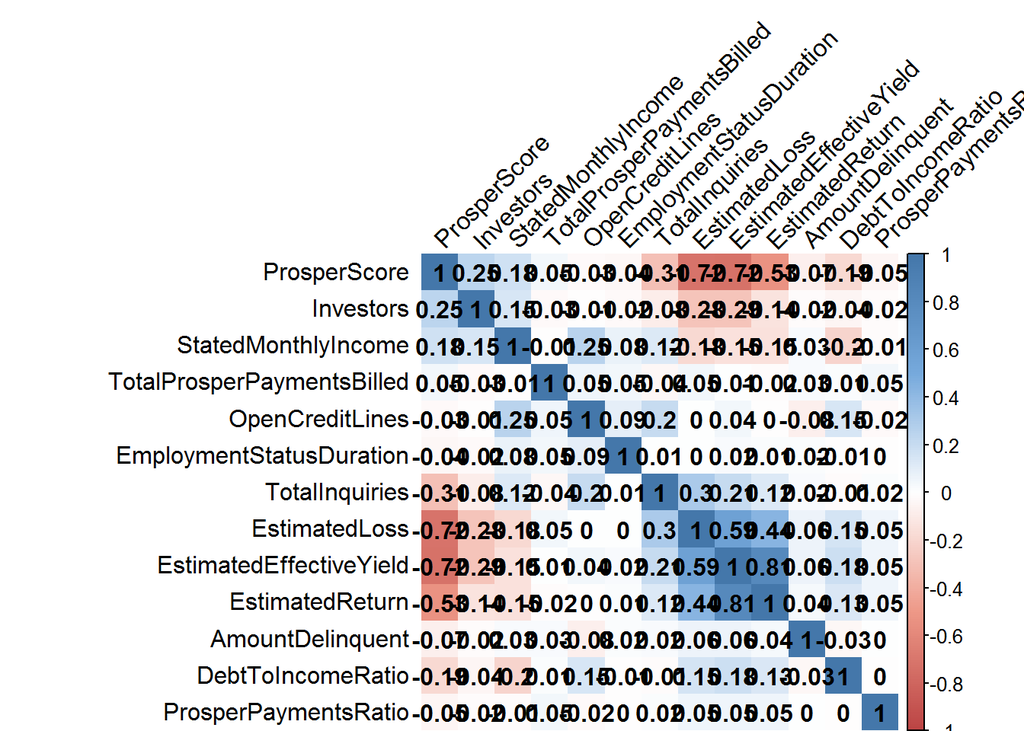

```
## [1] "Observed interesting relations between ProsperScore and some variables: 1) Weak positive correlation with Investors \n      2) Negative correlation with EstimatedReturn\n      3) Weak negative correlation with TotalInquiries"
```

```
## [1] "Surprisingly for other variables didnot observe any strong correlations, most of these were zero to weak correlations. Only other strong correlation(>0.7) is between EstimatedEffectiveYield and EstimatedReturn"
```

```
## [1] "The above results could have been due to not segmenting the results based on variables of factor type, like ListingCategory, Term, LoanStatus and ProsperScore. Further analysis would take these variables into consideration."
```

[output not shown]

[output not shown]

```
## [1] "Below Set of plots explore the relationship between Estimated Return and other varibles of the 1st Set"
```

```
## [1] "EstimatedReturn vs ProsperScore"
```

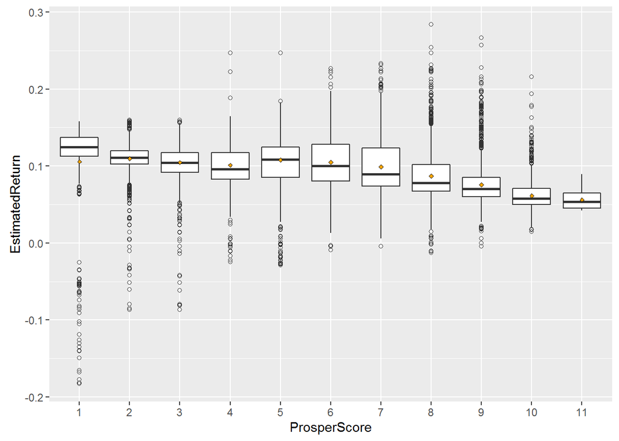

[output not shown]

```
## [1] "EstimatedReturn vs ListingCategory"
```

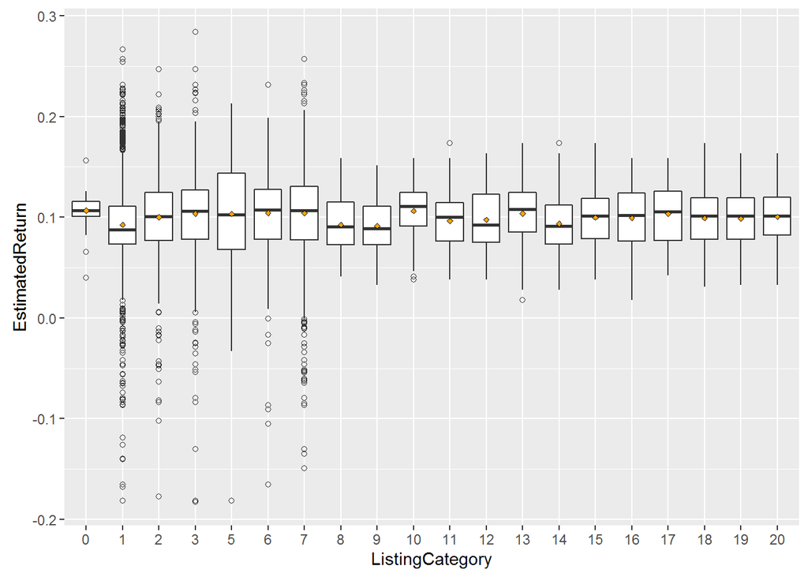

```
## [1] "Redrawing the same graph by computing Mean and Median of EstimatedReturn vs ListingCategory"
```

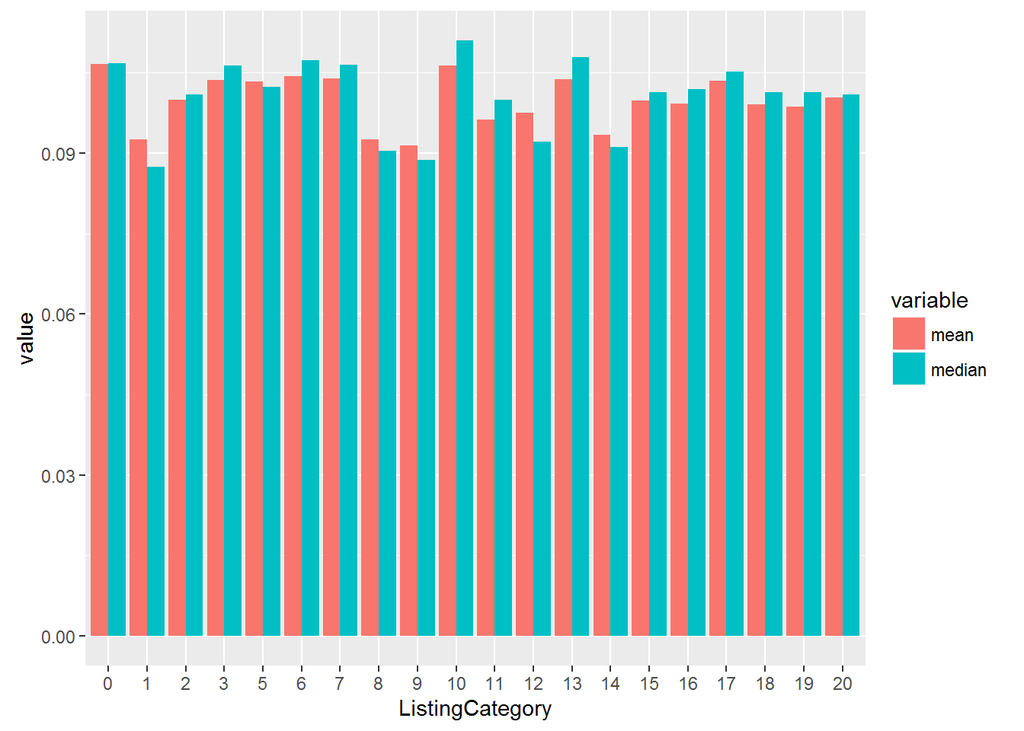

```
## [1] "Debt Consolidation has the lowest median and the 2nd least mean EstimatedReturn"
```

```
## [1] "EstimatedReturn vs LoanStatus"
```

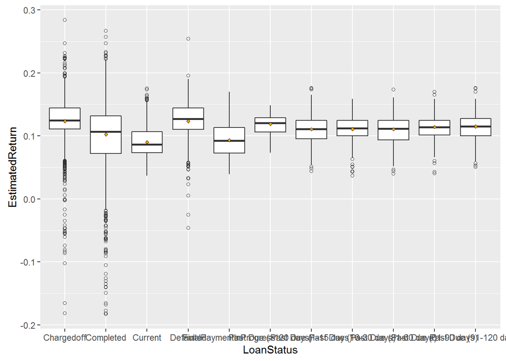

```
## [1] "Redrawing the mean and of EstimatedReturn vs LoanStatus, but only considering Chargedoff, Completed, Current and Defaulted LoanStatus"
```

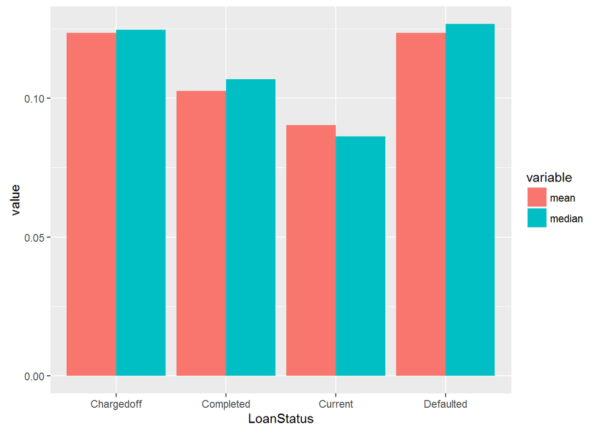

```
## [1] "Estimatedreturn is highest for ChargedOff and Defaulted loans, and the least EstimatedReturn is for CurrentLoans"
```

```
## [1] "EstimatedReturn vs Term"
```

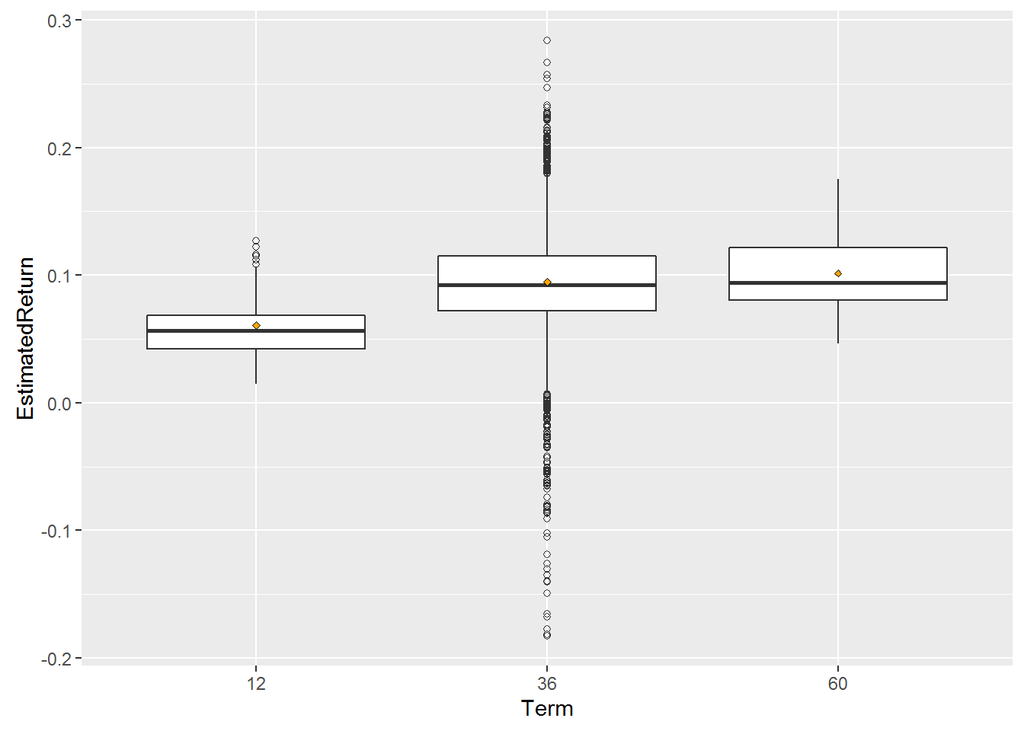

```
## [1] "Mean EstimatedReturn are almost comparable for 3 yr and 5yr Terms, however, the variance is highest for 3 yr Term"
```

```
## [1] "EstimatedReturn vs LoanOriginalAmount"
```

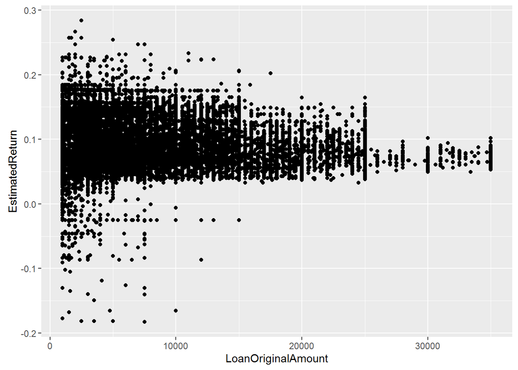

```
## [1] "Clearly the variance is very high for loans with low LoanOriginalAmount, however there is no strong correlation"
```

```
## [1] "EstimatedLoss vs LoanStatus"
```

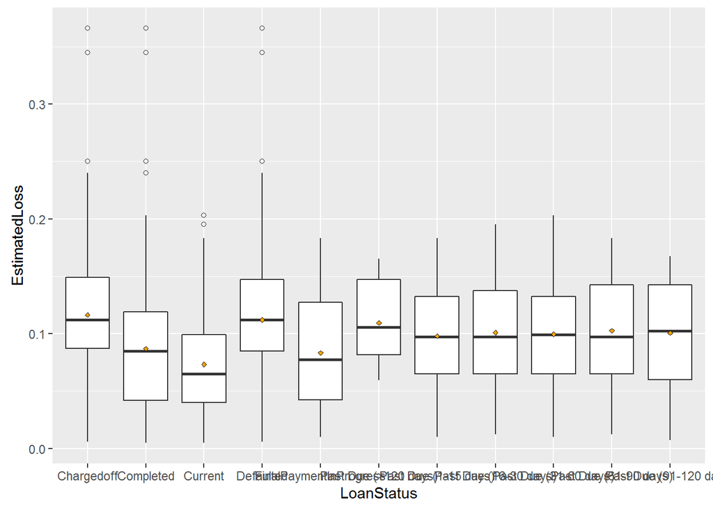

```
## [1] "EstimatedLoss are highest for Chargedoff and Defaulted Loans and least for current Loan"
```

[output not shown]

```
## [1] "StatedMonthlyIncome vs LoanStatus"
```

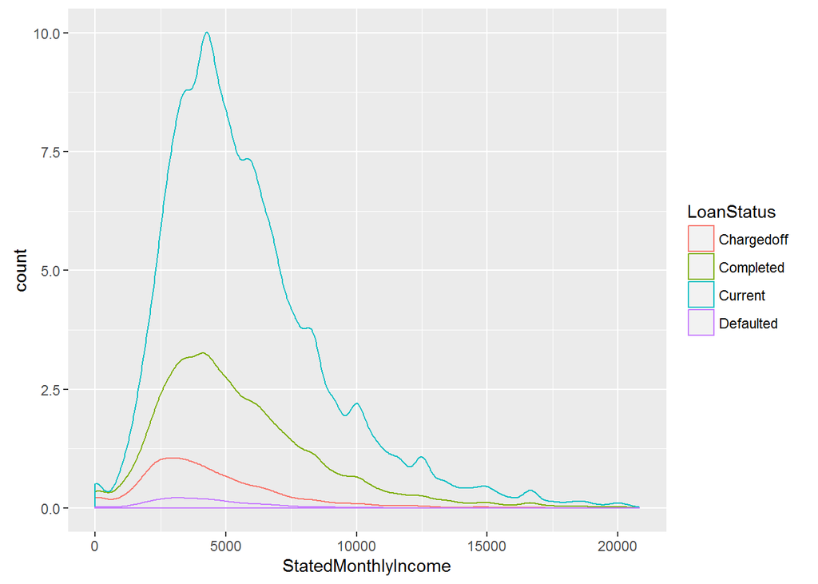

```
## [1] "The distributions are positively skewed, but did not draw any major hypothesis"
```

```
## [1] "OpenCreditLines vs LoanStatus"
```

```
## [1] "A bit of a dead End, there is not much conclusion that can be drawn here"
```

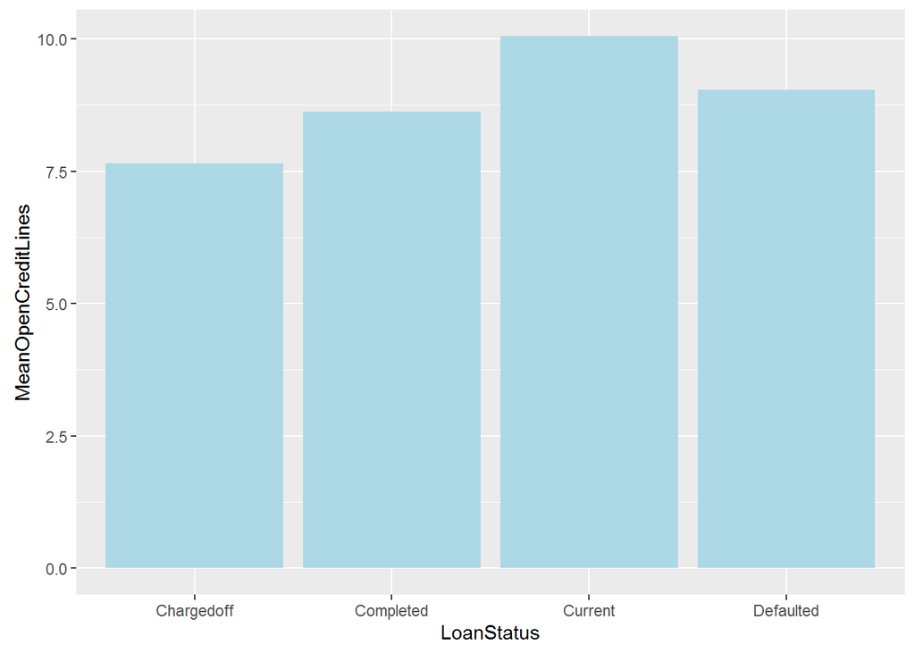

```
## [1] "TotalInquiries vs LoanStatus"
```

```
## [1] "Difference in MeanTotalInquiries for Completed vs Defaulted and Chargedoff LoanStatus is not very substanial."
```

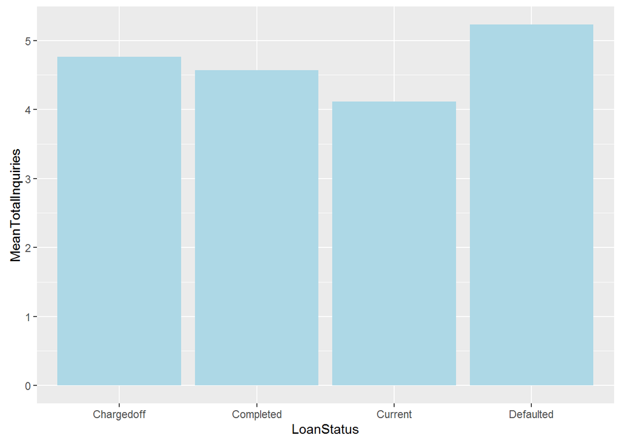

```
## [1] "EmploymentStatusDuration vs LoanStatus"
```

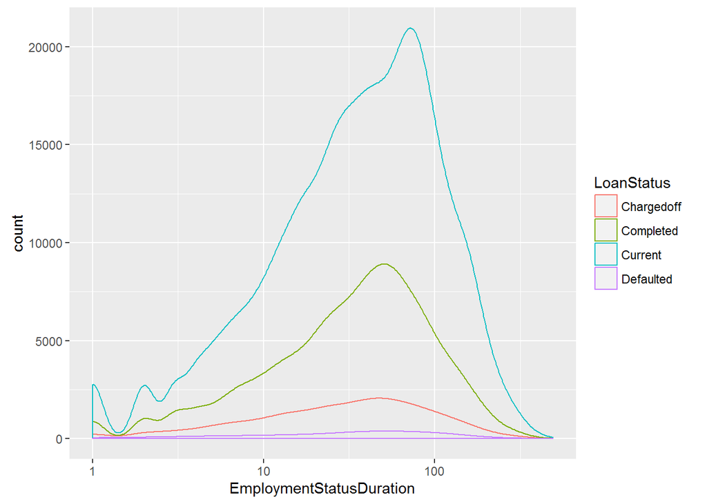

```
## [1] "Current and Completed LoanStatus follow LogNormal Distribution, whereas Chargedoff and Defaulted are platykurptic."
```

```
## [1] "DebtToIncomeRatio vs LoanStatus"
```

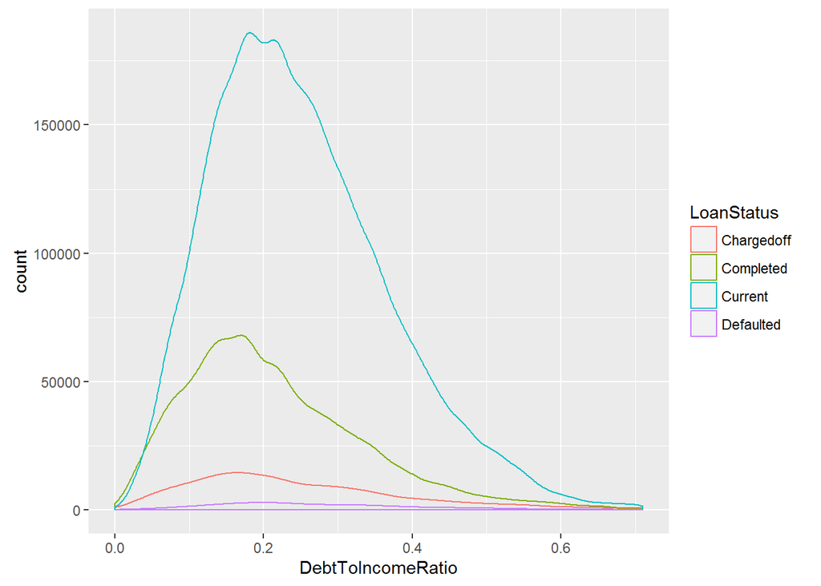

```
## [1] "Current and Completed LoanStatus follow Normal Distribution, whereas Chargedoff and Defaulted are platykurptic."
```

```
## [1] "LoanOriginalAmount vs LoanStatus"
```

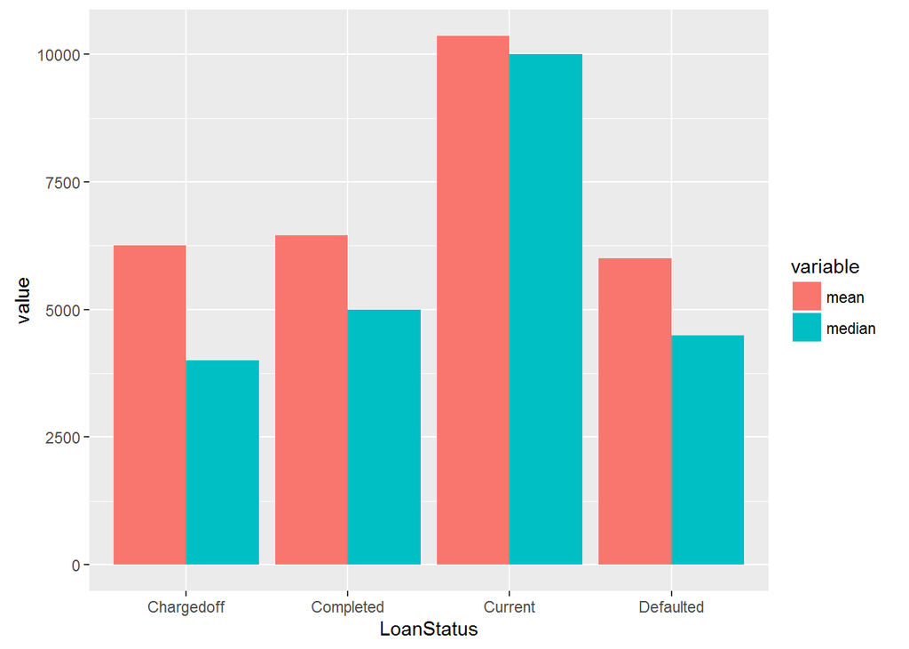

```
## [1] "median LoanOriginalAmount for Completed LoanStatus is slightly higher than Chargedoff and Defaulted LoanStatus. both mean and median are the highest for Current LoanStatus"
```

```
## [1] "ProsperScore vs LoanStatus"
```

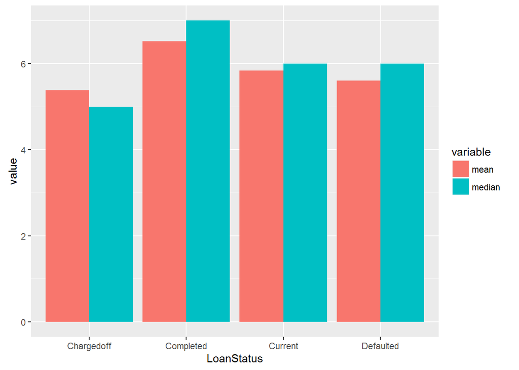

```
## [1] "The median ProsperScore for CompletedLoans is 7, whereas for Chargedoff and Defaulted loans is 5, 6 respectively. This shows the ProsperScore are fairly consistent with Risk Estimates, riskier loans are more likely to Default or Chargedoff"
```

```
## [1] "ListingCraetionDate vs ProsperScore"
```

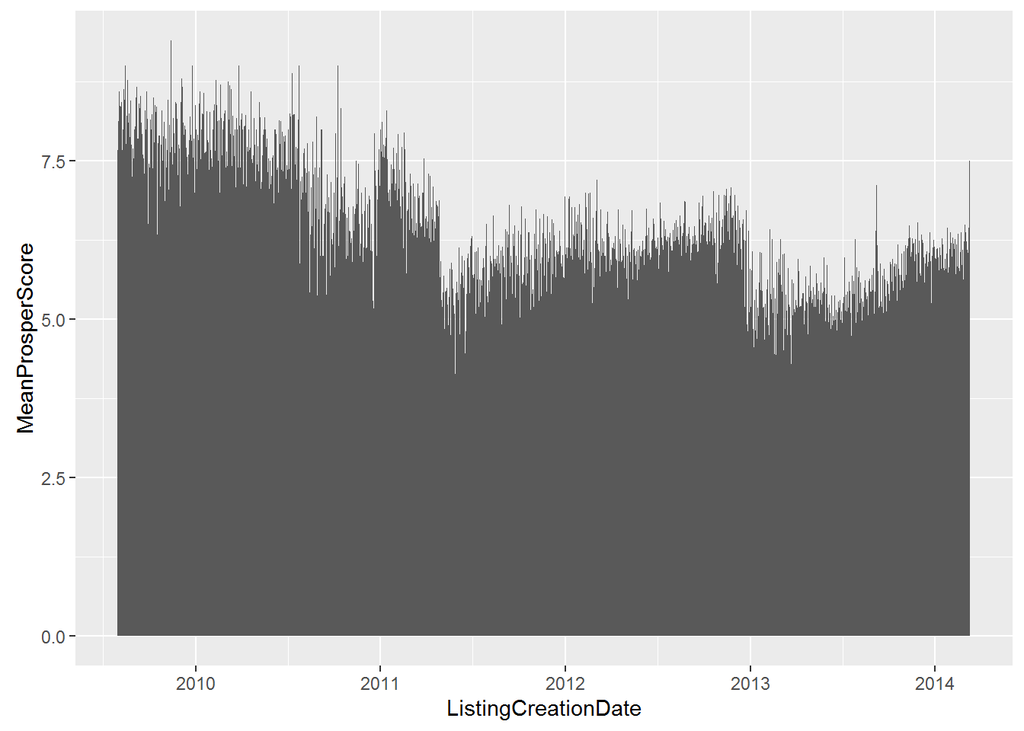

```
## [1] "Post July 2009, we see that ProsperScore is decreasing and at the start of 2013, it was the least and post-2013 it is increasing, It shows the service accomodating people with less ProsperScores"
```

```
## [1] "Investors with Single Investments in all LoanStatus"
```

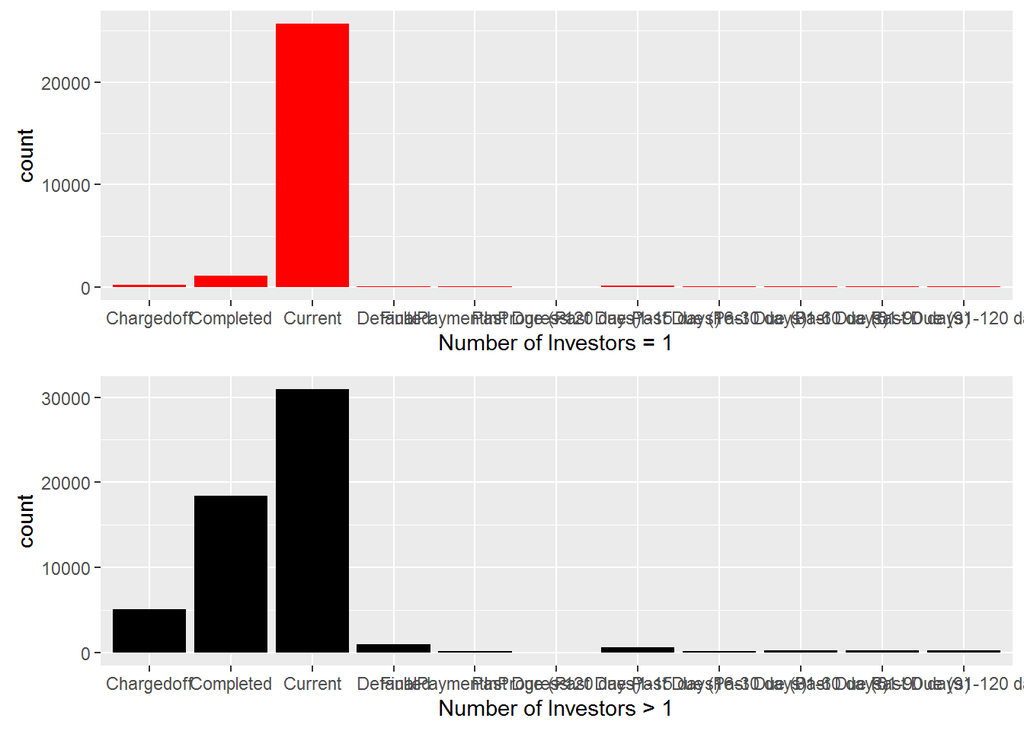

```
## [1] "Fairly high percent of single Investors have Invested in CurrentLoans, but the number of loans completed is higher for Investors>1"
```

# Bivariate Analysis

### Talk about some of the relationships you observed in this part of the investigation. How did the feature(s) of interest vary with other features in the dataset?

##### I segregated the varibales into 2 sets and analysed the relationships of feature of interest in each set. EstimatedReturn vs ProsperScore gave good insights, Loans with high risk gave higher returns on average and 1st quartile.

##### For LoanStatus I was mainly concerned with Current, Completed, Defaulted and Chargedoff LoanStatus, to see how loans in these types differ. I observed that EstimatedLoss is highest for Chargedoff and Defaulted Loans and least for Current Loan

##### Did not observe strong correlation of EstimatedReturn with LoanOriginalAmount. But there was high variance at low LoanOriginalAmount, and variance decresed as the LoanOriginalAmount Increased.

##### In LoanOriginalAmount vs LoanStatus, median LoanOriginalAmount for Completed LoanStatus is slightly higher than Chargedoff and Defaulted LoanStatus

##### Finally, In most other plots wrt to variable of interest, I could not make strong hypothesis from the plot as there was neither strong corelation nor any siginificant difference between types of LoanStatus

### Did you observe any interesting relationships between the other features (not the main feature(s) of interest)?

##### In the corrplot, there were weak correlations between ProsperScore and Investors and TotalInquiries and a strong correlation with EstimatedEffectiveYield. Surpirsingly for other varibales, there were no strong correlation observed. Only one other strong correlation was observed between EstimatedEffectiveYield and EstimatedReturn. This seems obvious.

##### Also, Fairly high percent of single Investors have Invested in CurrentLoans, but the number of completed Loans is higher for Investors>1 than for single Investors

### What was the strongest relationship you found?

##### EstimatedReturn vs ProsperScore was the strongest relation I found. Interestingly loans with highest risk have provided highest median and mean returns and Least riskiest Loans have given lowest returns. Also, 1st quartile return is highest for most risky loan